# P3 ANEMIA

**Estudio sobre factores detrás de la incidencia de anemia en niños de Apurímac en 2020**

1. IMPORTANCIA

**Audiencia:** Personas en interés de los niveles de anemia en la región de Apurímac y el país.

**- ¿Es el estudio de interés para la audiencia?**

Sí, la problemática de la anemia actualmente es de mucha importancia en el sector salud en el Perú, más aun en las zonas andinas del país, ya que esta condición perdura como uno de los principales problemas en múltiples regiones, afectando principalmente a los más jóvenes. Debido a esto, queremos obtener la relación que la prevalencia de esta condición pueda tener con el nivel de alimentación y nutrición, y cómo esta influye en cuestiones de salud. Así, se podrá dar una mayor consideración a la salud de los niños a nivel de la región, para garantizarles un mejor desarrollo y del mismo modo asegurar un buen futuro para los futuras generaciones del país.

**- ¿Qué información se desea aportar al final del estudio?**

La información que se desea aportar es una vista general de las tendencias que se pueden observar entre los niños de diferentes partes de Apurímac y las tasas de anemia que se puedan observar. De este modo, se podrán delimitar las regiones que más padecen de esta problemática, y determinar hasta qué punto múltiples variables influencian esta problemática.

**- ¿Por qué se justifica nuestro estudio?**

El presente estudio está justificado por los siguientes puntos:

- Es **factible** porque existe una base de datos con un tamaño de muestra numeroso (19499 muestras) y con varias variables tanto cuantitativas como cualitativas.
- Es **específico** porque aborda una problemática recurrente en el Perú, enfocándose principalmente en el departamento de Apurímac.
- Es **poco estudiado**, ya que las personas de esta región son a menudo excluidos y reciben menor atención en temas de salud y bienestar, hasta el punto que la anemia constituye una problemática particular.
- Empleará el **tiempo requerido**, ya que contamos con la información necesaria para poder investigar la relación entre la anemia y otros factores en la base de datos, al solo faltar darle un correcto análisis.
2. OBJETIVOS

**General:**

Analizar los diversos factores que pueden afectar en la salud de los niños de Apurímac y así poder relacionarlos con las estadísticas que indiquen el estado de la anemia de los niños de Apurímac en 2020.

**Específicos:**

- Establecer variables vinculantes relacionadas al aspecto físico que pueden afectar la salud de los niños de Apurimac.
- Analizar la concentración de hemoglobina en la sangre, entre otros indicadores de anemia, en los niños menores de 5 años en la región de Apurímac.
- Relacionar las variables cuantitativas de la base de datos.
3. MARCO TEÓRICO

##### **3.1. Definiciones importantes:**

- **MINSA:** Se conoce como MINSA al Ministerio de Salud del Perú.
- **Anemia:** Se trata de una condición en la que la cantidad de glóbulos rojos o hemoglobina en la sangre se ven disminuidos a largo plazo.

##### **3.2. Población objetivo:**

Los niños que viven en Apurímac y que se encuentren dentro del rango de edad establecido como objeto de estudio.

##### **3.3. Tipo de muestreo:**

Las muestras serán obtenidas de una base de datos del MINSA de acceso público.

##### **3.4. Sesgo:**

Nuestros datos provienen de una base de datos, por lo que tenemos que considerar algunos sesgos presentes en nuestro estudio hasta el momento:

- **Sesgo de extraer registros:** Nosotros no recolectamos los datos, por lo que no podemos evidenciar ni garantizar que todos hayan sido registrados de manera correcta.

- **Sesgo de publicación:** La base de datos esta constituida de las observaciones de quienes participaron del proceso de recopilación de muestras, por lo que no tenemos datos de aquellas personas que no se registraron al momento de la recolección de datos.

##### **3.5. Unidades muestrales:**

Los niños menores de 5 años en el departamento de Apurímac.

##### **3.6. Las bases de datos:**

La base de datos es un documento que contiene 19499 muestras de las unidades muestrales previamente mencionadas. Esta será el pilar de nuestro proyecto, ya que cuenta con la información esencial para llevar a cabo todo nuestro análisis.

Se cargan las librerías necesarias para importar la base de datos:

```r
library(readr)
library(dplyr)
```

Ahora, se puede importar la base de datos dentro de la variable ‘datos1’.

```r
datos1 <- read_csv("Ninos_APURIMAC.csv")
```

4. LIMPIEZA DE DATOS

Después de esto, se hace la respectiva limpieza de datos para excluir los que no tienen variables que requerimos para el estudio. Nos quedamos con las observaciones que tienen lecturas completas para todas las variables que seleccionamos previamente, y las demás son retiradas. Estos nuevos datos se insertan en la variable ‘datos’.

También se crea una nueva columna del IMC (Índice de masa corporal) a base de la talla y el peso con los que ya se cuentan. Se emplea la siguiente ecuación:

$$IMC=\frac{masa}{talla^2}$$

Del mismo modo, se emplea el ajuste de la concentración de hemoglobina respecto a la altura sobre el nivel del mar. Esto se consigue con la siguiente formula del CDC:

$$Ajuste={-0.032*(altura*0.0032808)+0.022*(altura*0.0032808)^2}$$

Se emplea esta formula debido a que la altura sobre el nivel del mar hace que aumente la concentración de hemoglobina en la sangre, por lo que es pertinente utilizar este ajuste para encontrar la concentración equivalente al de un individuo que viva al nivel del mar. Aunque esta formula solo es aplicable para alturas por encima de los 1000 msnm, no hay ningún individuo de la muestra que viva bajo esta altura, por lo cual no consideramos este detalle al realizar el ajuste.

```r
ANEMIA_A<-ANEMIA1[!(is.na(ANEMIA1$Hemoglobina)==TRUE),]
ANEMIA_A$Hemoglobina[ANEMIA_A$Hemoglobina<=0]<-NA


ANEMIA_A$Qaliwarma[ANEMIA_A$Qaliwarma==1]<-"Accede"
ANEMIA_A$Qaliwarma[ANEMIA_A$Qaliwarma==0]<-"No Accede"
ANEMIA_A$Juntos[ANEMIA_A$Juntos==1]<-"Accede"
ANEMIA_A$Juntos[ANEMIA_A$Juntos==0]<-"No Accede"
ANEMIA<-ANEMIA_A[complete.cases(ANEMIA_A),]

ANEMIA$IMC<-ANEMIA$Peso/((ANEMIA$Talla/100)^2)
ANEMIA$Hemoglobina_Ajustada <- with(ANEMIA, ANEMIA$Hemoglobina -(-0.032*(ANEMIA$AlturaREN*0.0032808)+0.022*(ANEMIA$AlturaREN*0.0032808)*(ANEMIA$AlturaREN*0.0032808)))
```

Seguidamente, podemos ver cuantos datos tenemos después de la limpieza.

```
## [1] "Número de observaciones completas:  4500"
```

```
## [1] "Número de observaciones incompletas después de limpieza:  0"
```

**Boxplot de edad por sexo**

Se puede ver que las distribuciones son casi iguales en los niños y las niñas. Por ende, los resultados ligados a la edad representan tanto a los niños como a las niñas.

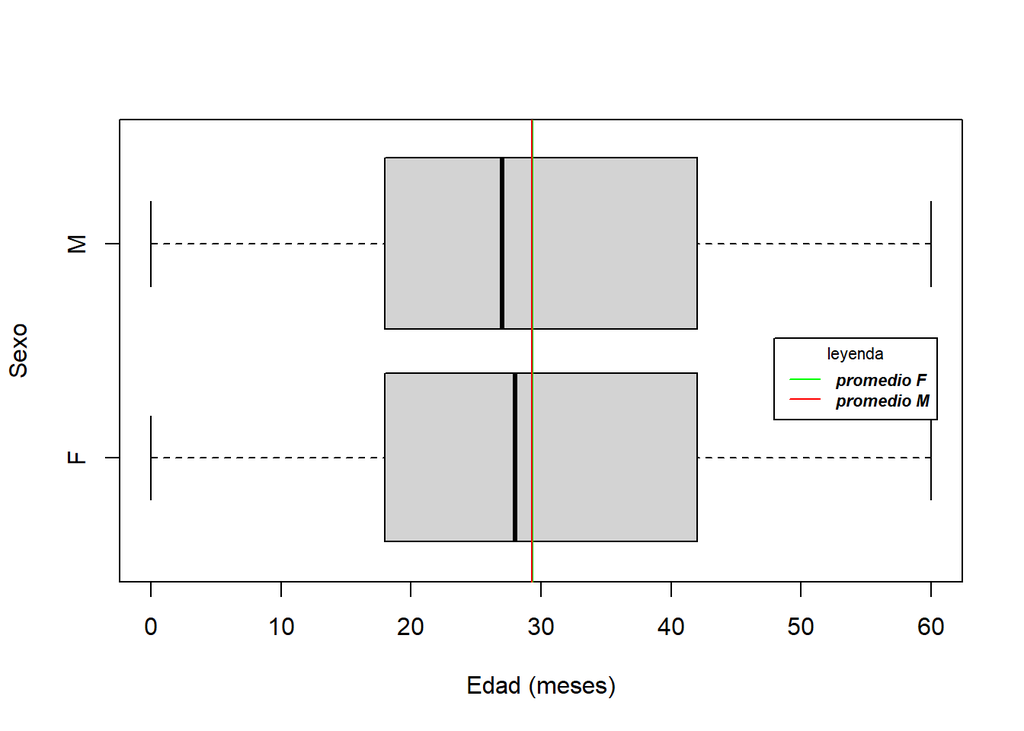

**Boxplot de peso por sexo**

Como se puede ver, las distribuciones de peso son similares para ambos sexos. Por ende, se puede considerar que los datos dependientes del peso son representativos para tanto niños como niñas en el estudio.

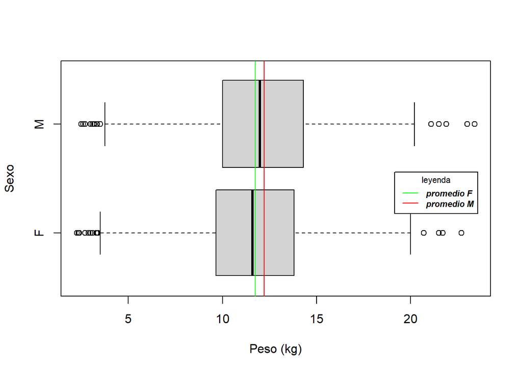

**Boxplot de hemoglobina por sexo**

En el caso de la hemoglobina, su concentración en la sangre es otra variable que está distribuida de manera similar en ambos sexos. No obstante, la mediana parece estar un poco por encima de la media en el caso de las mujeres.

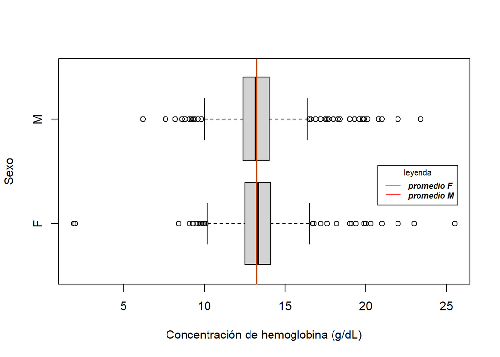

**Boxplot de hemoglobina ajustada por sexo**

Por el lado de la hemoglobina ajustada, sus concentraciones también están similarmente distribuidas en ambos sexos.

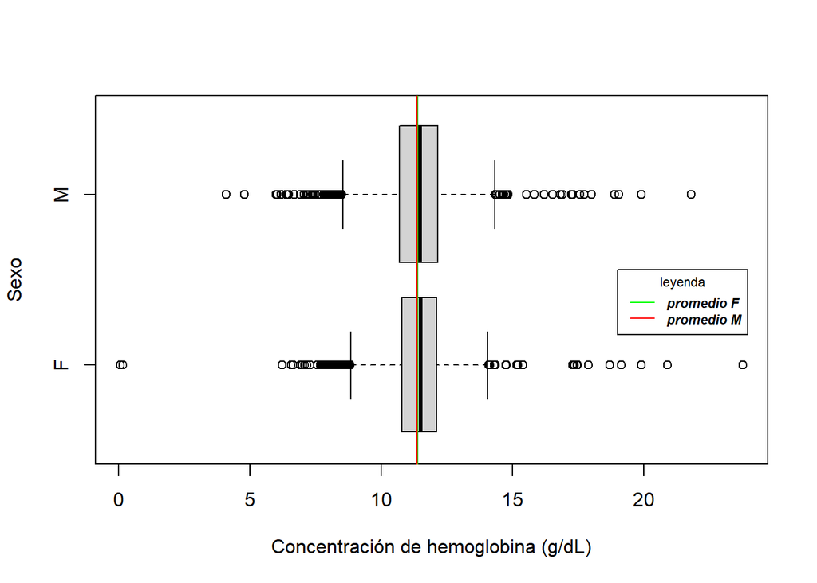

**Boxplot de talla por sexo**

En el caso de la talla, se puede ver que la distribución es muy similar para ambos sexos. En general los hombres tienen una mayor altura, y tanto la media, la mediana, y los rangos son un poco más altos en el caso de los varones.

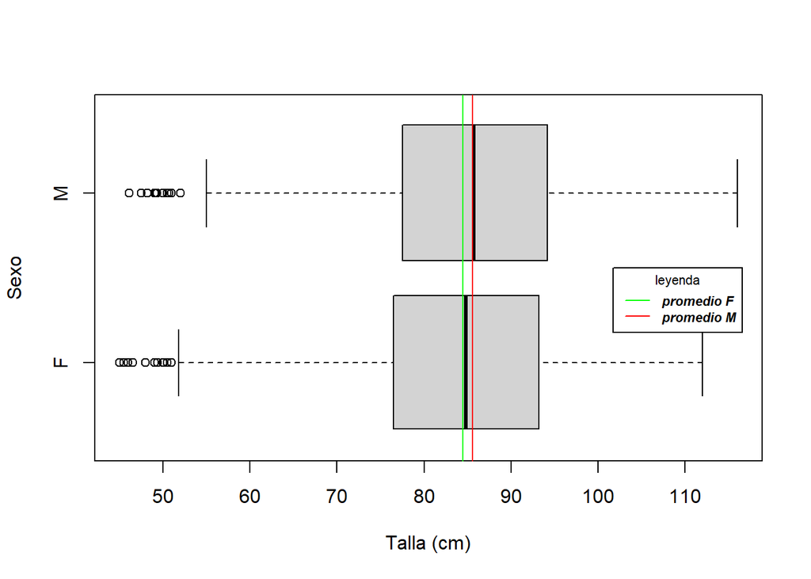

5. VARIABLES DE ESTUDIO

6. DESCRIPCIONES DE LAS VARIABLES DE ESTUDIO

**Peso**

Este gráfico muestra que la mayoría de los niños y niñas están entre los 8 y 16 kg.

```
##    Min. 1st Qu.  Median    Mean 3rd Qu.    Max.
##    2.27    9.83   11.80   11.98   14.10   23.40
```

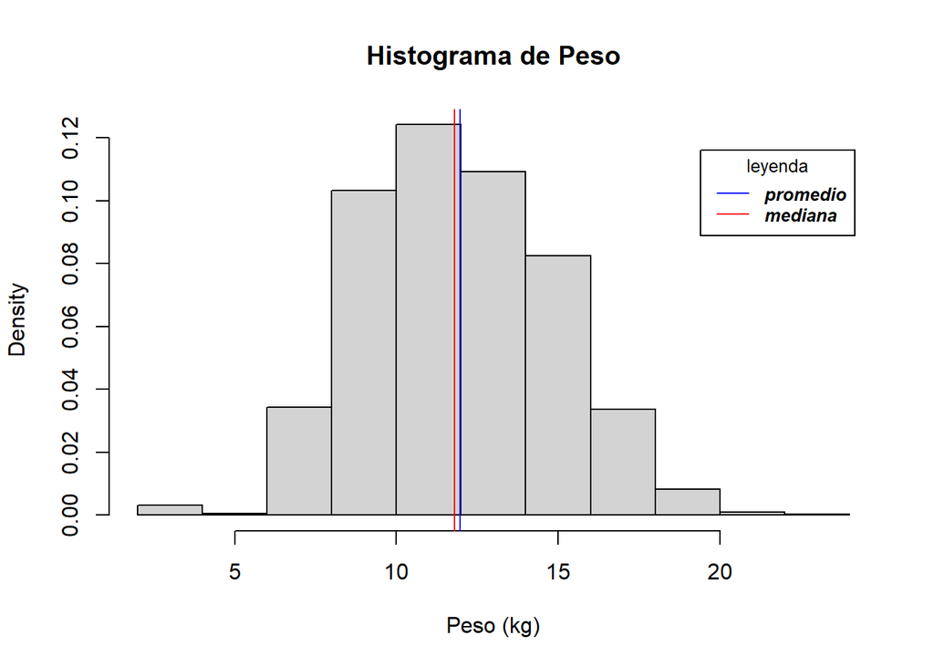

**Talla**

El siguiente histograma muestra la relación entre las cantidades de niños y sus respectivas tallas.

```
##    Min. 1st Qu.  Median    Mean 3rd Qu.    Max.
##   45.00   77.10   85.20   85.05   93.83  116.00
```

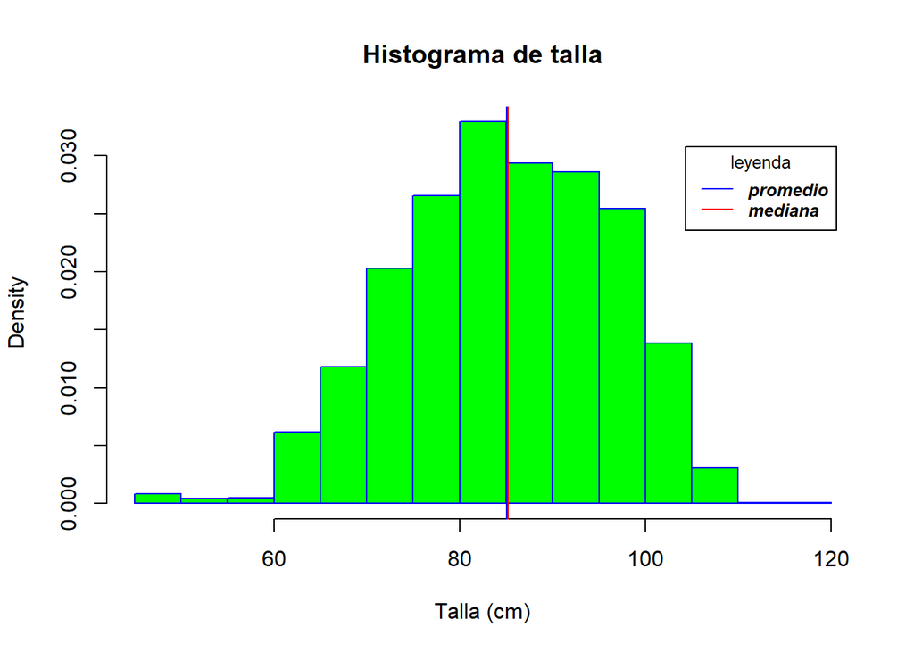

Cabe resaltar que la desnutrición está relacionada tanto al peso corporal como a la talla. Debido a esto, es factible emplear los valores Z del peso y la talla para la respectiva edad de cada individuo estudiado. Podremos comparar sus concentraciones de hemoglobina en la sangre con su estas variables y determinar la posible existencia de una relación. También se puede acudir al IMC para hacer una categorización sensata del nivel de nutrición de cada individuo.

Esto se puede afirmar debido a que la talla y el peso están relacionados, como se puede ver en la gráfica. Asimismo, se presenta la correlación de pearson.

```
## [1] "Correlación entre la talla y el peso:"
```

```
## [1] 0.9320483
```

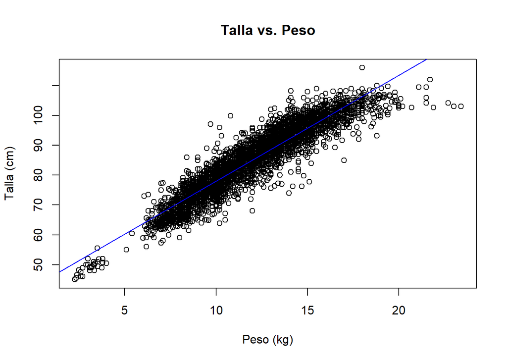

La misma tendencia se puede apreciar, aunque a menor grado, en el caso de los valores Z de la talla-edad y el peso-edad.

```
## [1] "Correlación entre la talla-edad y el peso-edad:"
```

```
## [1] 0.6740186
```

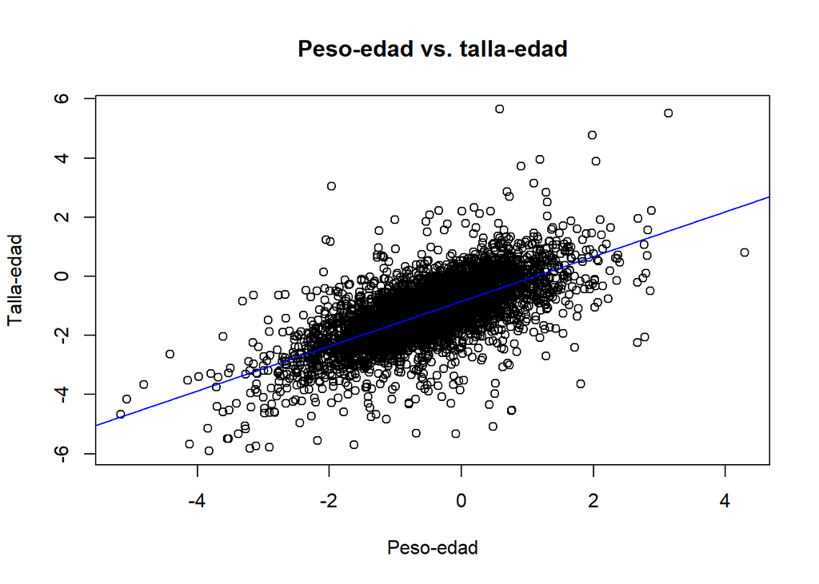

**Altura**

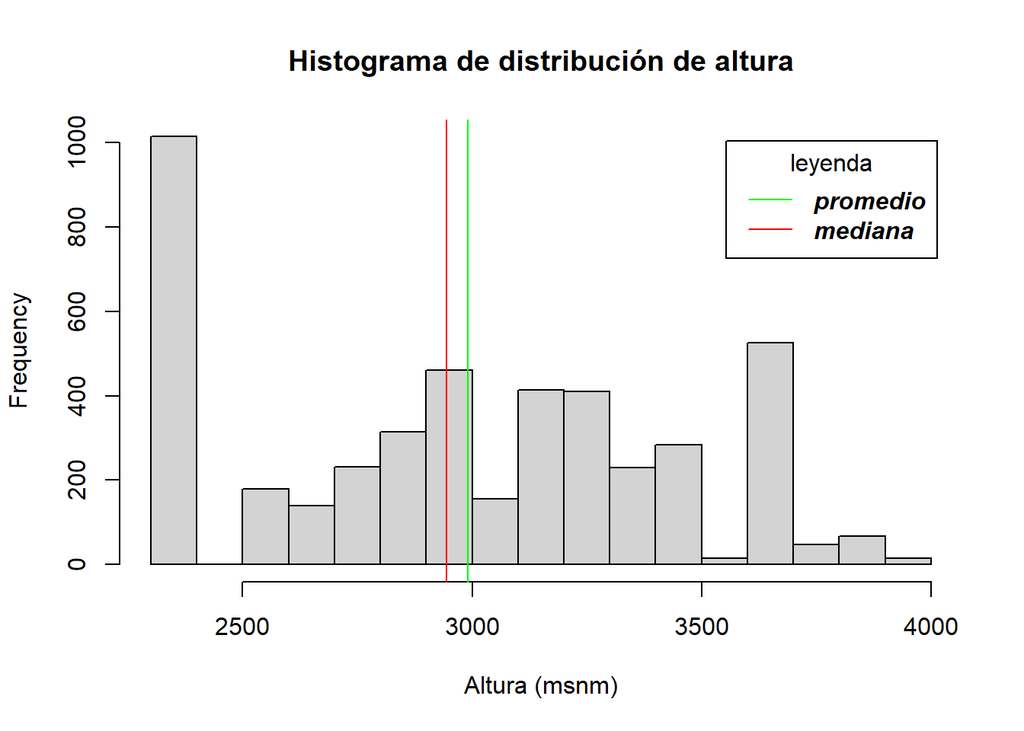

**Índice de masa corporal (IMC)**

Respecto al IMC, esta variable es de suma importancia para nuestro estudio debido a que nos permite categorizar cada individuo como desnutrido, normal, o con sobrepeso. Un rango normal para un infante se da entre los 16.5 y 22.5 kg/m^2. Según la gráfica de cajas, se puede ver que más de la mitad de la población del estudio está desnutrida y que hay muy pocos casos de sobrepeso (a la derecha de la línea amarilla).

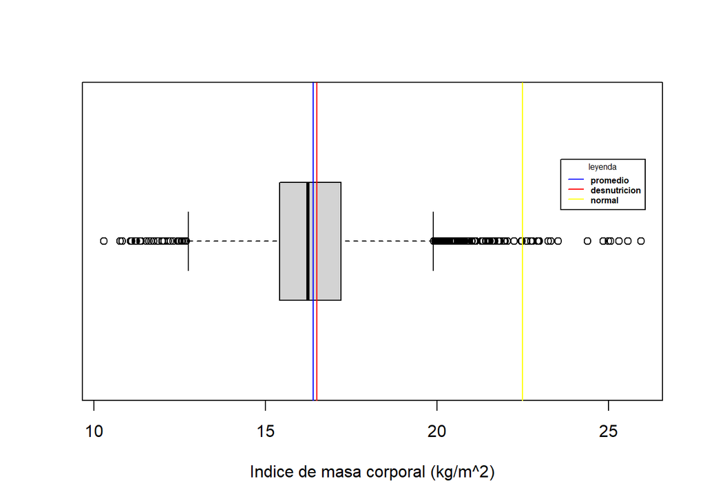

En efecto, aqui se muestra el porcentaje de desnutridos, constituído por quienes tienen un IMC menor a 16.5 kg/m^2.

```
## [1] "Porcentaje de desnutridos: 57.6222222222222 %"
```

La siguiente tabla tabula la cantidad de individuos respecto a su categoría de nutrición según el IMC.

[output not shown]

**Variables estandarizadas**

El siguiente histograma muestra la distribución de los valores Z de la talla-edad para los niños de Apurímac. Se puede ver que sigue una tendencia de distribución normal, pero con un promedio mucho menor que el promedio mundial.

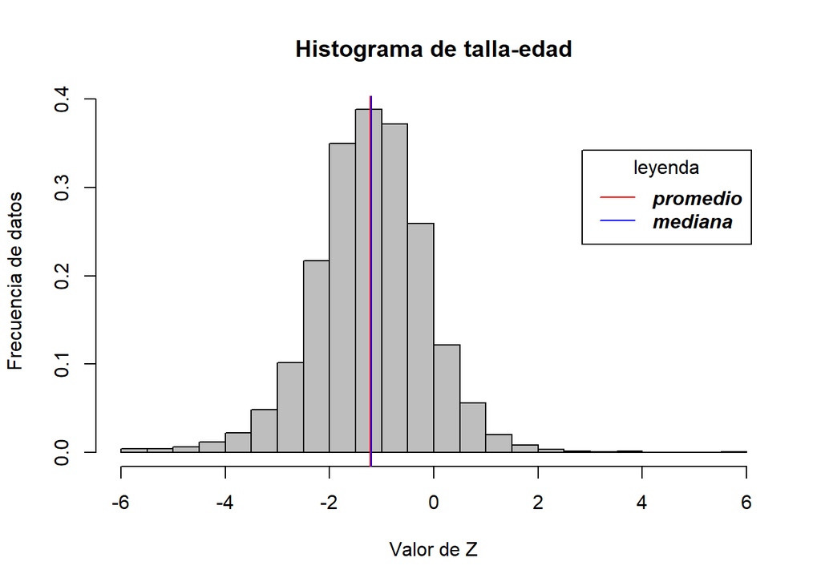

En el caso de los valores Z del peso-edad se puede ver que estos también siguen una tendencia de distribución normal, con un promedio ligeramente menor que el promedio mundial.

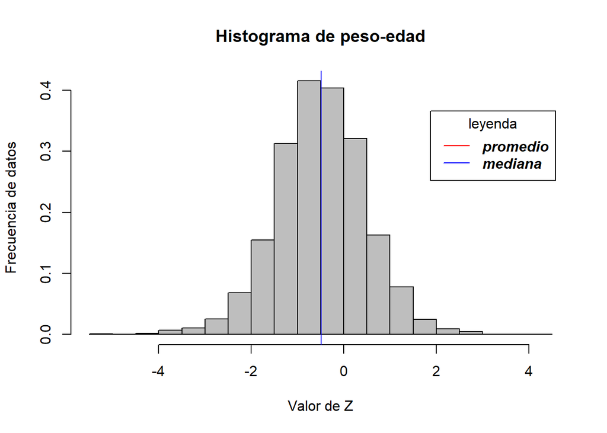

**Qaliwarma y Juntos**

Qaliwarma y Juntos son dos programas sociales existentes a nivel nacional. Qaliwarma se enfoca en la alimentación de los niños, mientras que Juntos está dirigido a las personas con una pobreza mayor al 40%. La siguiente gráfica de barras muestra las proporciones de acceso a cada programa por los niños de Apurímac.

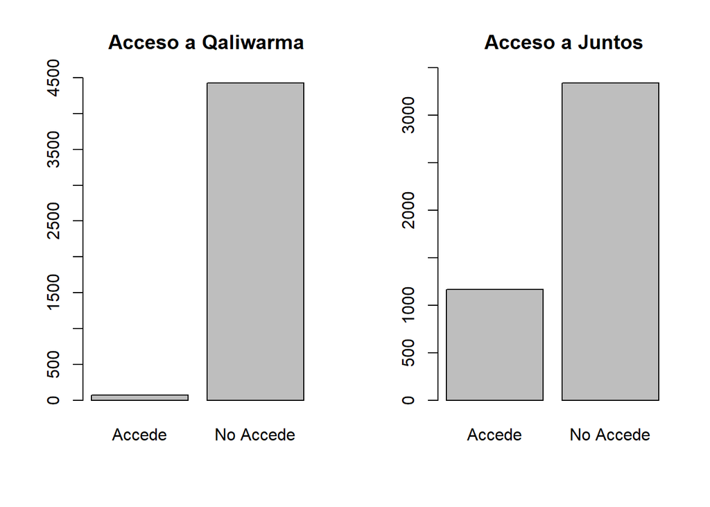

La siguiente tabla muestra las tres provincias con más niños y niñas que acceden a ambos programas a la vez. Es interesante que Abancay es una de las dos ciudades más grandes de Apurímac, lo cual sugiere que el acceso a estos programas es mayor en entornos urbanos.

| PROVINCIA | CANTIDAD |
| --- | --- |
| ABANCAY | 17 |
| CHINCHEROS | 11 |
| AYMARAES | 9 |

**Hemoglobina**

La concentración de la hemoglobina es una de las variables más importantes del estudio debido a que esta es la única que permite identificar la prevalencia de anemia en un individuo. Debido a esto, es importante intentar que esta sea lo más representativa posible. Es por este motivo que se emplea el ajuste por la altura mencionado anteriormente.

Aquí se observan algunos indicadores de las concentraciones de hemoglobina en la muestra. Es evidente que al ajustarse los datos, estos disminuyen de manera generalizada. Esto es de esperarse, ya que la altura infla el valor de la concentración de la hemoglobina en la sangre a causa de la menor presión atmosférica.

```
## [1] "Resumen de concentración de hemoglobina (g/dL): "
```

```
##    Min. 1st Qu.  Median    Mean 3rd Qu.    Max.
##    1.90   12.40   13.30   13.24   14.00   25.50
```

```
## [1] "Resumen de concentración de hemoglobina ajustada al nivel del mar (g/dL): "
```

```
##     Min.  1st Qu.   Median     Mean  3rd Qu.     Max.
##  0.07585 10.76020 11.51058 11.38698 12.14995 23.77983
```

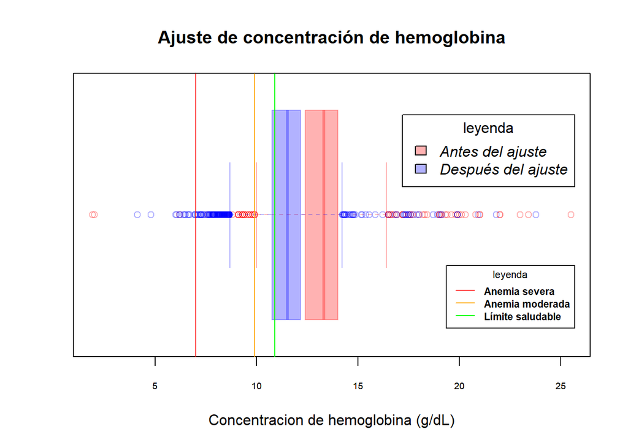

Por otro lado, esta gráfica muestra tan solo la distribución de los datos después de llevar a cabo el ajuste. Se puede ver que la anemia prevalece en alrededor del 25% de los niños y niñas en la muestra.

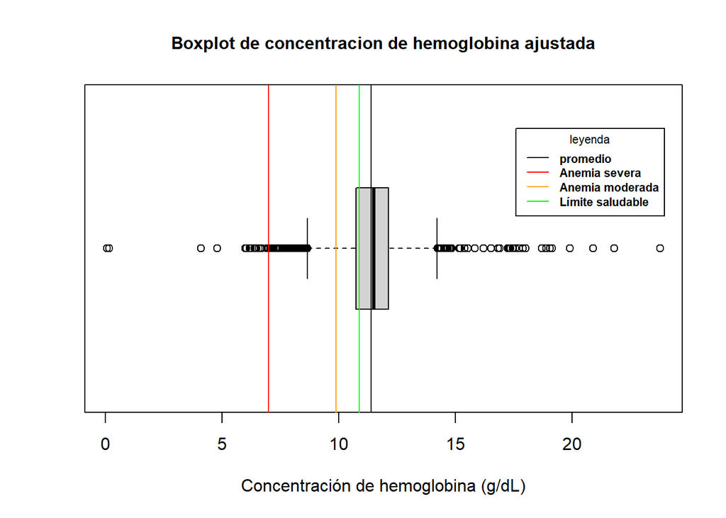

Este histograma de frecuencia de las concentraciones de hemoglobina demuestra que se puede ver una distribución cercana a una distribución normal y que incluso pocos casos atípicos llegan a ser extremos.

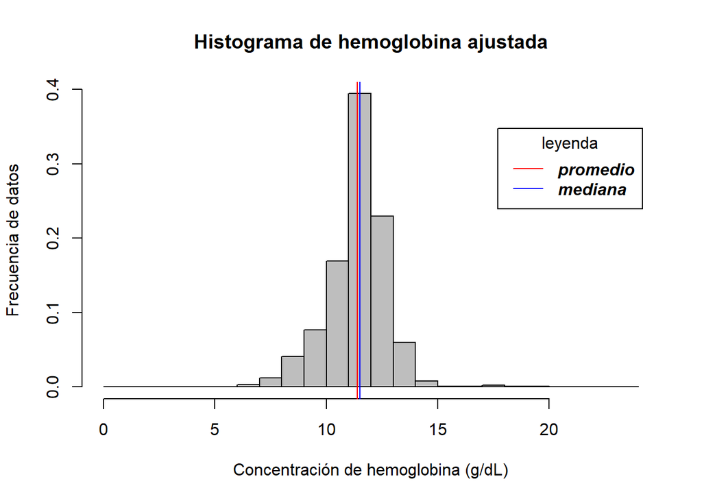

Las siguientes gráficas de cajas muestran las distribuciones de la concentración de hemoglobina en la sangre por provincia. Se puede ver que en algunas provincias los valores están más dispersos, pero en general todas las provincias siguen un patrón similar.

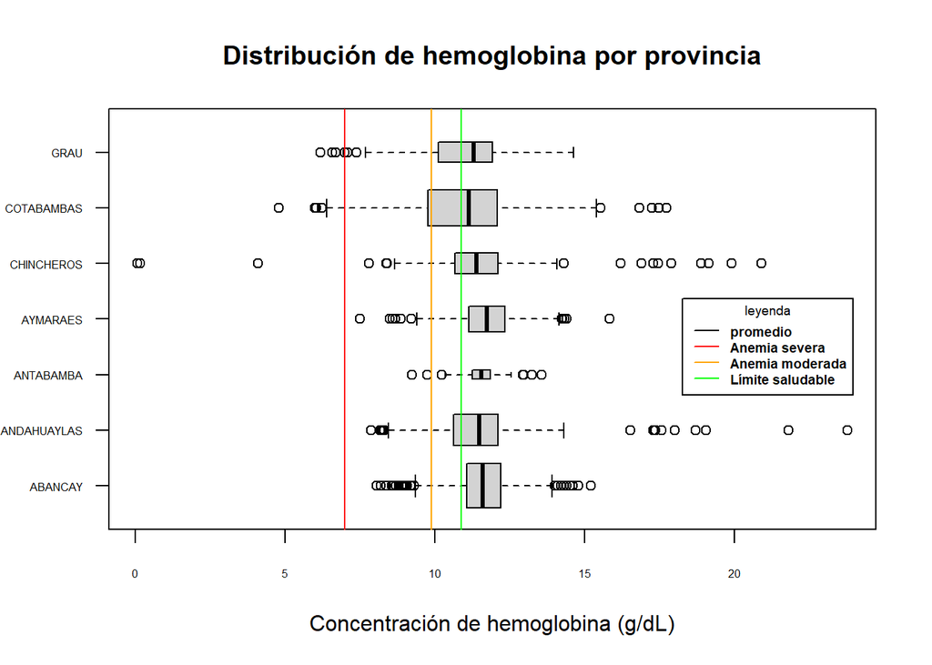

La siguiente tabla presenta las tres provincias de Apurímac con más niños y niñas con casos moderados y graves de anemia. Cabe resaltar que Cotabambas encabece la lista aunque solo tenga al 22% de la población del departamento y no tenga centros urbanos relevantes. Se sabe que esta es la provincia con la mayor tasa de pobreza en el departamento (Ministerio de Economía y Finanzas, 2011).

| DISTRITO | CANTIDAD |
| --- | --- |
| COTABAMBAS | 469 |
| ABANCAY | 319 |
| ANDAHUAYLAS | 237 |

Estas gráficas de cajas muestran las distribuciones de las concentraciones de hemoglobina en la sangre respecto a la altura sobre el nivel del mar. Se puede observar que casi todas están distribuidas igualmente, y que los datos por encima de los 3750 msnm no tienen datos anómalos. Esto puede deberse a que hayan pocos datos para este rango. Es alarmante que en las mayores alturas se observan altas tasas de anemia; estas incluso superan el 50% en el rango mas alto.

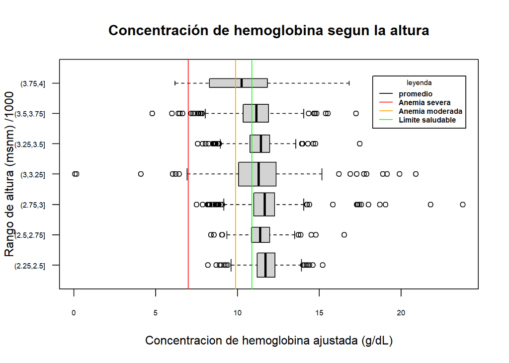

Ahora procedemos a observar la relación entre la concentración de hemoglobina en la sangre y otras variables numéricas:

En cuanto al IMC, aunque se planteaba que este y la concentración de la hemoglobina podrían estar relacionados, un análisis estadístico concluye que no guardan ninguna correlación lineal.

```
## [1] "Correlación entre el IMC y la concentración de hemoglobina:"
```

```
## [1] -0.06727151
```

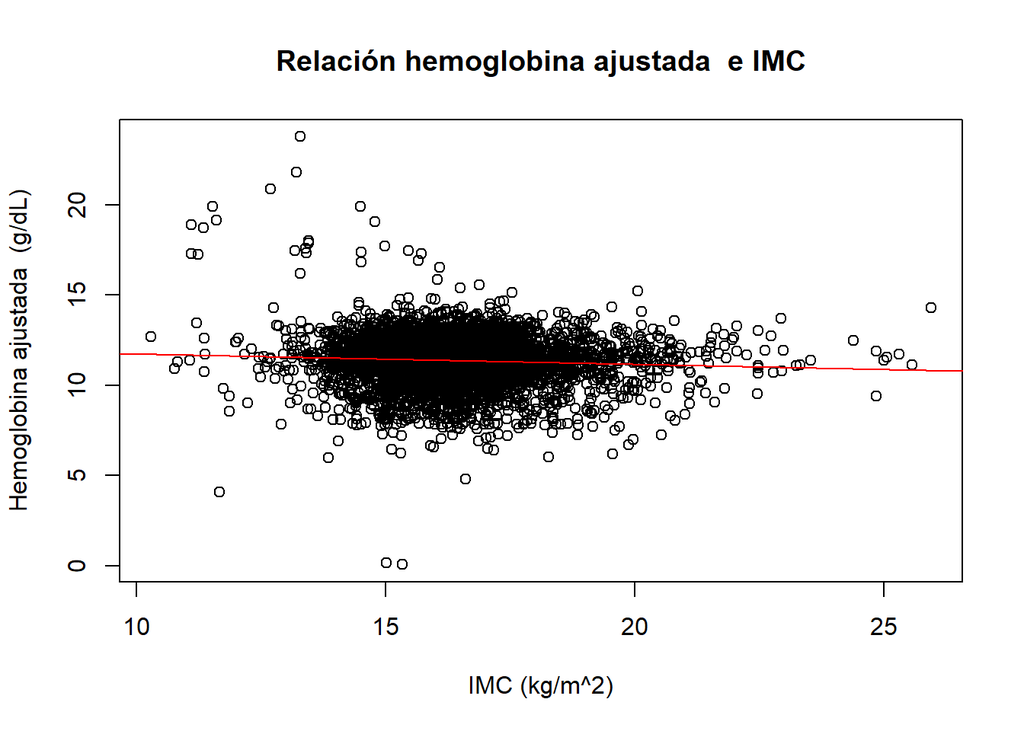

Se ha planteado también que debido al rol de la nutrición en el crecimiento y el desarrollo, la talla y la concentración de hemoglobina podrían estar relacionadas entre sí. No obstante, no tienen una correlación lineal significante.

```
## [1] "Correlación entre la talla y la concentración de hemoglobina:"
```

```
## [1] 0.1185678
```

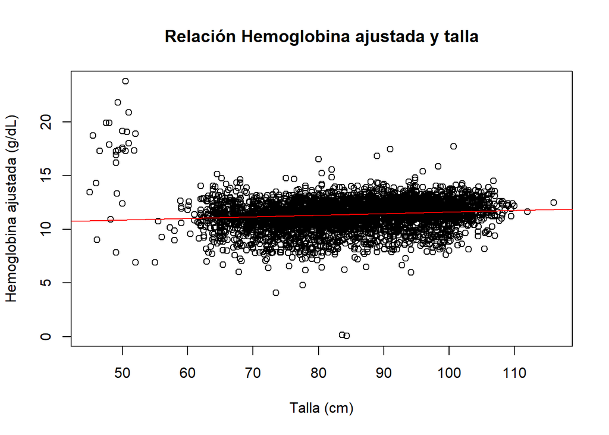

```
## [1] "Correlación entre la altura y la concentración de hemoglobina ajustada:"
```

```
## [1] -0.2246559
```

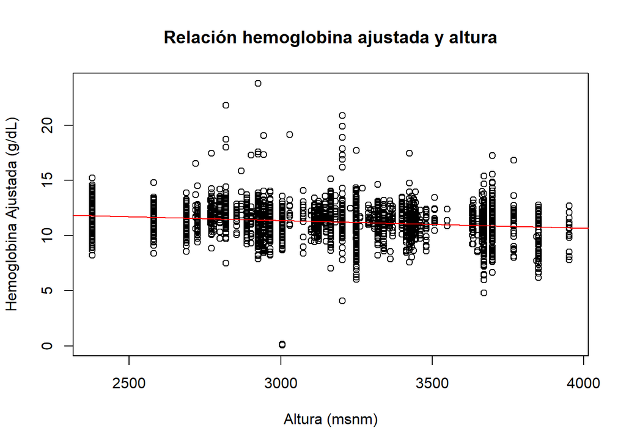

**Variables aleatorias discretas**

A continuación, procederemos a ver algunos ejemplos de probabilidad condicional con nuestras variables aleatorias discretas. Estos permitirán conocer las implicancias de las relaciones entre nuestras variables más a fondo.

Analizando el caso de los individuos en el quinto percentil inferior de la talla para su edad (Z < -1.64), se puede ver que la incidencia de esta baja estatura es mucho mayor en entre quienes presentan anemia grave (concentración de hemoglobina en la sangre menor a 7 g/dL).

```
## [1] "Con anemia grave: 0.470588235294118"
```

```
## [1] "Sin anemia: 0.301273885350318"
```

El siguiente histograma ilustra la situación. Se puede ver que una proporción considerable de los niños y niñas con anemia grave se encuentra en el quinto percentil inferior de la altura para su edad respectiva.

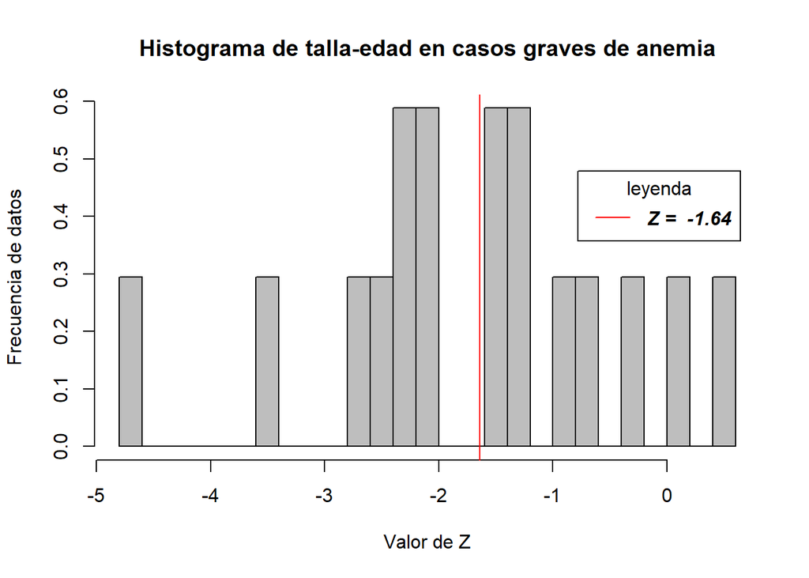

Se puede ver que en el caso de quienes no presentan anemia, esta situación es menos marcada.

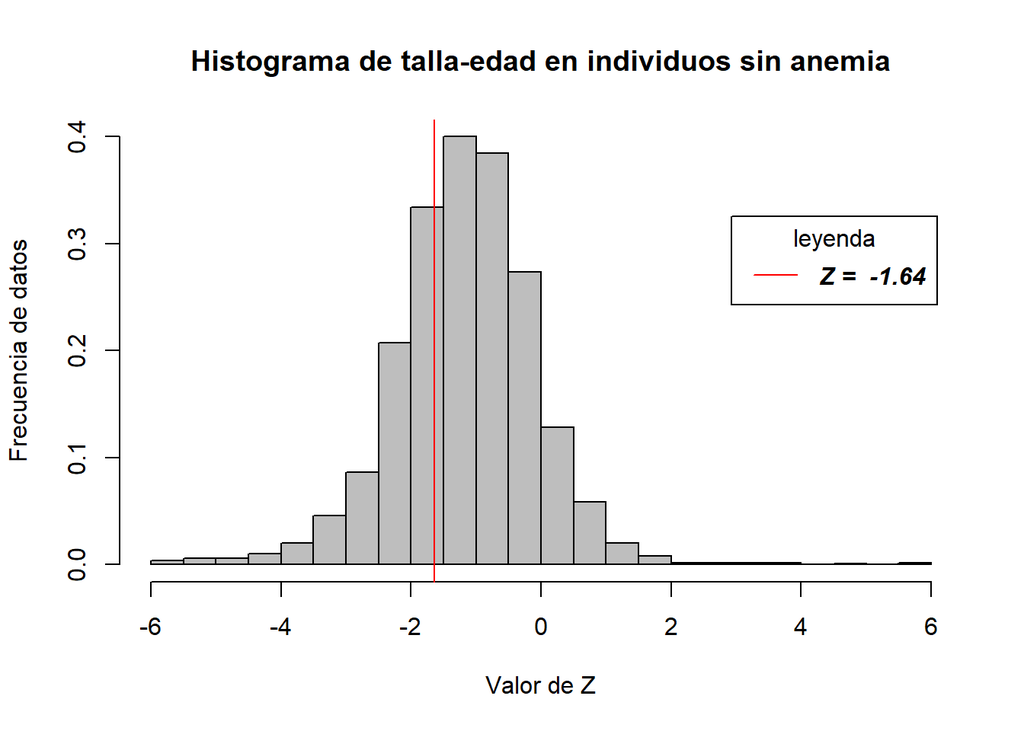

Las siguientes cifras muestran las incidencias de anemia moderada y grave en tres distintos rangos de altura. Es importante considerar que tanto Andahuaylas como Abancay se encuentran por debajo de los 2930 msnm, por lo que se pueden apreciar las diferencias entre el entorno urbano y rural. Los 3700 msnm fueron elegidos arbitrariamente ya que esta es la primera altura en la que se ven más casos de anemia que casos sanos.

```
## [1] "Probablidad de tener anemia si vives por debajo de los 2930 msnm: 0.190655969797074"
```

```
## [1] "Probablidad de tener anemia si vives por encima de los 2930 msnm: 0.401511969760605"
```

```
## [1] "Probablidad de tener anemia si vives por encima de los 3700 msnm: 0.592307692307692"
```

¿Cual es la probabilidad de tener anemia si vives por debajo de de los 2930 msnm?
$$X_1\sim\mathsf{Ber}(p)$$
con
$$p=0.1907$$
¿Cual es la probabilidad de tener anemia si vives por encima de de los 2930 msnm? El modelo para esta pregunta se puede manifestar por Bernoulli.
$$X_2\sim\mathsf{Ber}(p)$$
con
$$p=0.4015$$

¿Cual es la probabilidad de tener anemia si vives por encima de de los 3700 msnm?
$$X_3\sim\mathsf{Ber}(p)$$
con
$$p=0.5923$$

Claramente se puede ver que los niños y niñas que viven a una altura mayor tienden a padecer anemia. Este comportamiento se puede explicar a través de factores externos como la incidencia climática y geográfica, la falta de acceso a alimentos balanceado, y otros más.

Estas proporciones se ilustran con el siguiente histograma. Se puede ver que por debajo de los 2930 msnm hay muchos menos casos de anemia.

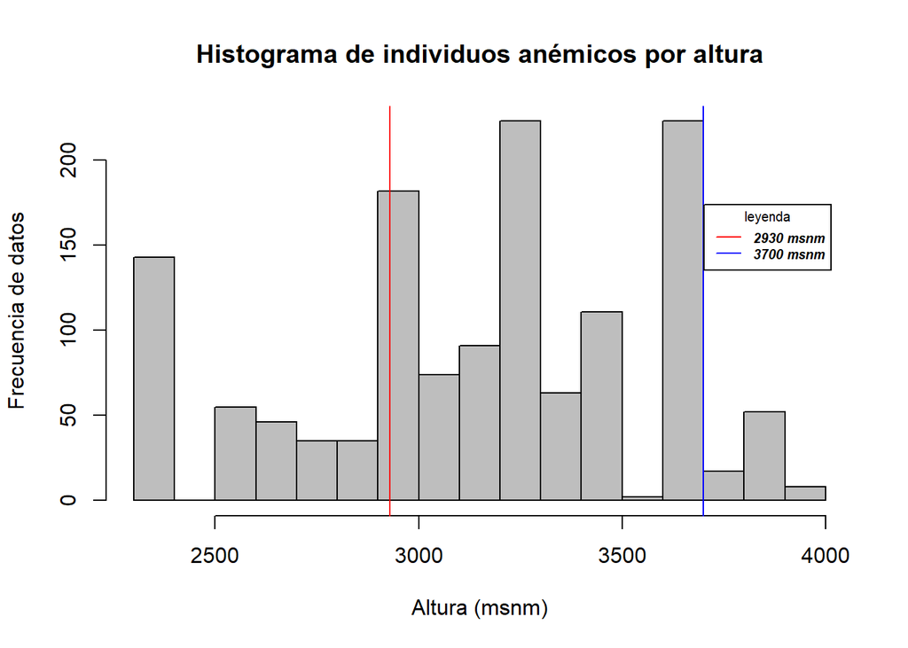

Esta situación se ilustra en los siguientes mosaicos:

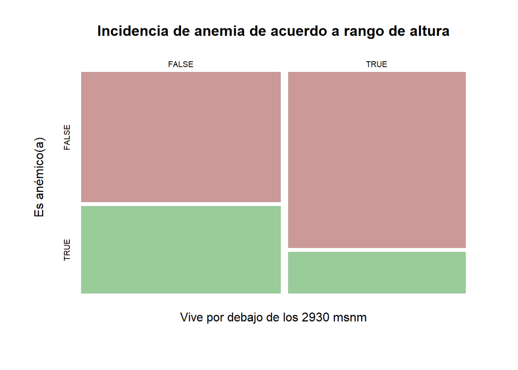

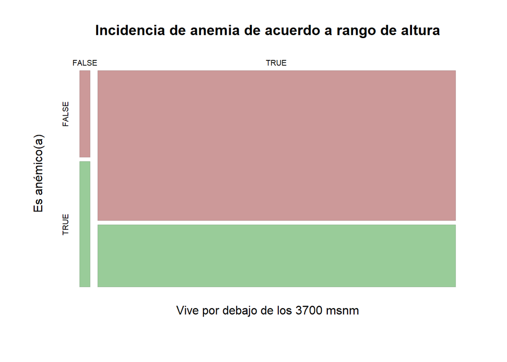

Finalmente, hay que considerar el rol de los programas de ayuda social. En el caso de Qaliwarma, se puede ver que este ayuda a reducir la incidencia de anemia de manera considerable.

```
## [1] "Probabilidad de que una persona del estudio no sea anémica dado que esta NO accede a Qaliwarma: 0.69573074316693"
```

```
## [1] "Probabilidad de que una persona del estudio no sea anémica dado que esta accede a Qaliwarma: 0.821917808219178"
```

No obstante, en el caso de Juntos se ve un patrón inverso. Esto puede deberse a la naturaleza del programa: Juntos es para personas con altos índices de pobreza, por lo que de por sí es más probable que los niños que acceden a estos programas no cuenten con una nutrición adecuada.

```
## [1] "La probabilidad de que una persona del estudio no sea anémica dado que esta NO accede a Juntos: 0.703925681750075"
```

```
## [1] "La probabilidad de que una persona del estudio no sea anémica dado que esta accede a Juntos: 0.680137575236458"
```

Esta situación se ilustra en los siguientes mosaicos:

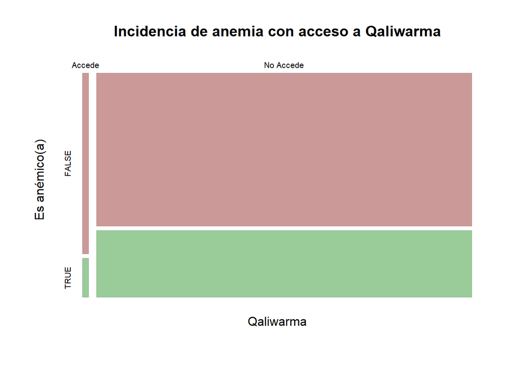

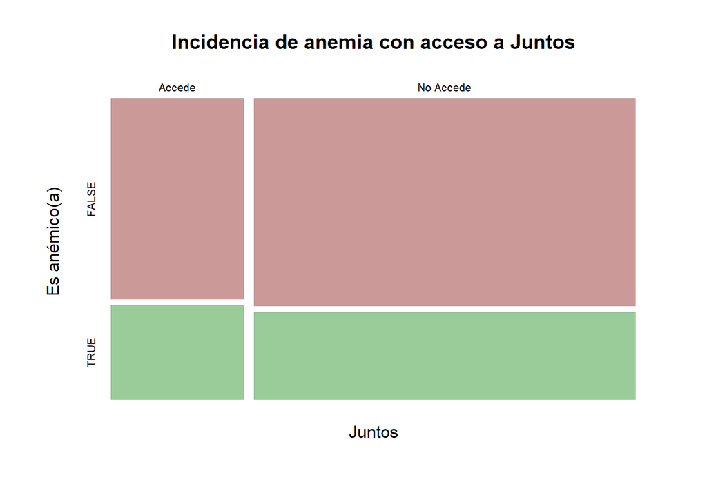

¿Cual es la probabilidad de que un niño acceda a Qaliwarma?

```
## [1] 0.01622222
```

$$X_1\sim\mathsf{Ber}(p)$$
con
$$p= 0.01622222$$
La probabilidad de que un niño(a) acceda a este programa social es mínima, por lo que podemos inferir que sus beneficios no son gozados por la mayoría de los niños a quienes está dirigido.

**Variables aleatorias continuas**